# Project 3

## B-IT Pattern Recognition

Presented on 4-Feb-2016 by:

- Abdullah Abdullah
- Can Güney Aksakallı
- Kang Cifong
- Umut Hatipoğlu

## Task 3.1

### Fun with k-means clustering

### The Data

```
200 samples of 2 dimensional data
```

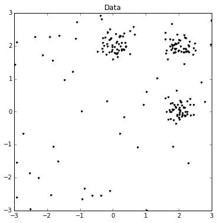

```python
mydata = demo_1_data()
```

### Lloyd's Algorithm

- Very Sensitive to initialization values
- Converges, but no guarantees (esp in case of bad initializations)
- No Guarantee about the results either
- Really Fast (if no catastrophy)

```
Converged after 4 iterations
Converged after 9 iterations
Converged after 3 iterations
```

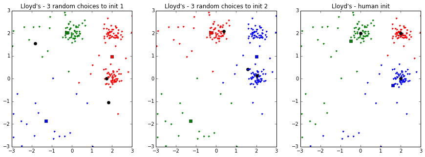

```python
demo_1_lloyd(mydata, 3)
```

### Different Similarity Measures

- The data does seem to have **Gaussian Blobs**
  - The problem with the data is different
- Different similarity metric will probably not give different results
  - Except in case of relatively bad similarity metrics

```
Converged after 5 iterations
Converged after 6 iterations
Converged after 5 iterations
Converged after 5 iterations
Converged after 4 iterations
Converged after 5 iterations
```

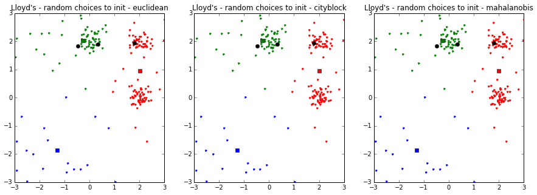

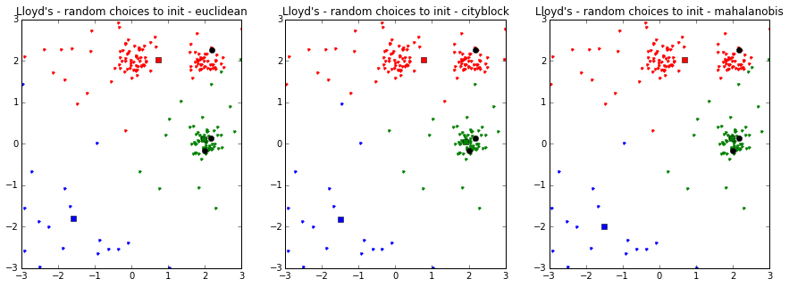

```python
demo_1_lloyd2(mydata, 3, ['euclidean', 'cityblock', 'mahalanobis'], 800)
demo_1_lloyd2(mydata, 3, ['euclidean', 'cityblock', 'mahalanobis'], 10)
```

### Hartigan's Algorithm

- Converges quickly
- Relatively Robust
- Still sensitive to initialization of classes

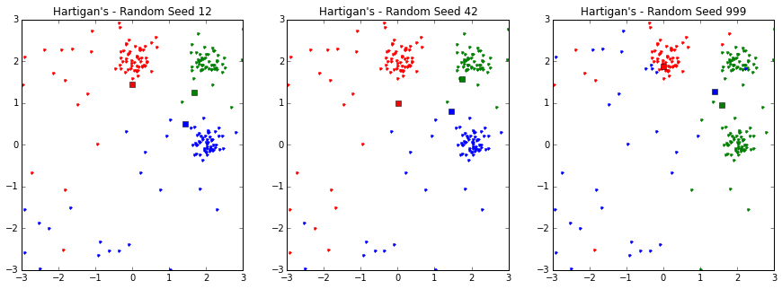

```python
demo_1_hart(mydata, 3, [12, 42, 999])  # These took some time to choose
```

#### Smarter Way?

- We couldn't figure out any smarter way, rather than :
  - only recalculate objective function for the current class
    - Not reliable, esp when the data is disproportionate among classes
  - calculate the change in objective function incrementally
  - Halved the number of data points for which the distance is calculated, compared to Naive
    - Does not fully utilize the potential, eg vectorization

```
m[ki] = (n[ki] / (n[ki] - 1)) * (m[ki] - x / n[ki])

normxkk = norm(x - m, axis=1)
eki = np.sum(norm(Xki - m[ki])) - normxkk[ki]
ediffki = eki - e[ki]

ediff = ediffki + normxkk

kw = np.argmin(ediff)
```

### MacQueen's Algorithm

- Convenient for streams
- Sensitive to order of data
  - Essentially, still sensitive to initialization

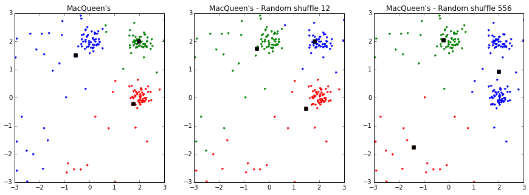

```python
demo_1_macqueen(mydata, 3, [12, 556])
```

### Run times!

```
Mac OSX - 10.11.3
2,9 GHz Intel Core i7 (On Battery)
Python 3.4

Lloyd - Naive
10 loops, best of 3: 57.9 ms per loop

Lloyd - 2
1000 loops, best of 3: 972 µs per loop

Lloyd - sklearn.cluster.KMeans
1000 loops, best of 3: 1.82 ms per loop

?? - scipy.cluster.vq.kmeans
1000 loops, best of 3: 683 µs per loop

?? - scipy.cluster.vq.kmeans2
1000 loops, best of 3: 796 µs per loop

Hartigan - Naive
1 loops, best of 3: 332 ms per loop

Hartigan - 2
10 loops, best of 3: 52 ms per loop

MacQueen - Naive
100 loops, best of 3: 17.2 ms per loop

MacQueen - 2 (numpy-ed)
100 loops, best of 3: 8.88 ms per loop
```

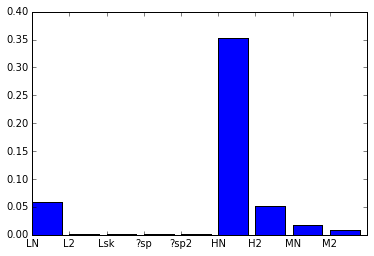

```python
np.random.seed(9000)
init_c = np.copy(mydata[np.random.choice(np.arange(mydata.shape[0]), size=3)])
demo_1_t()
```

## Task 3.2

### Spectral Clustering

### Syllabus

- Apply K-means
- Apply Spectral Clustering
- Apply Spectral Clustering using Andrew Ng's Alorithm

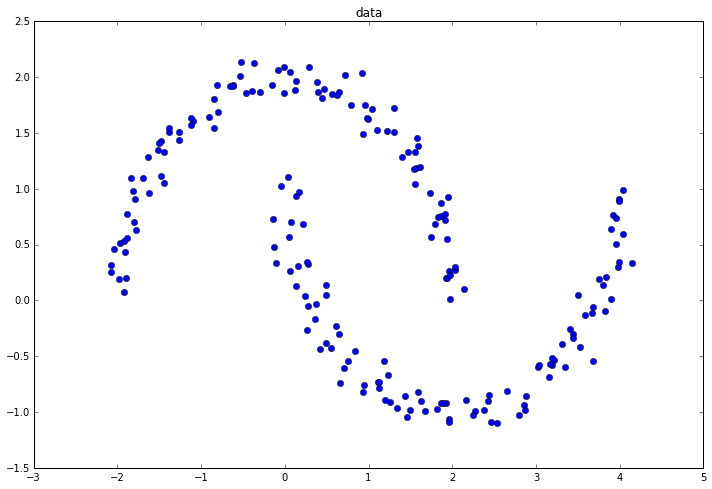

```python
my_data = demo_2_1()
```

### Apply K-means on Data

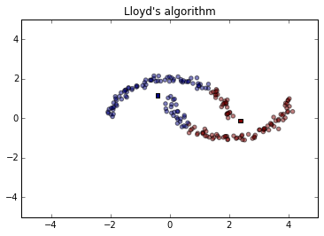

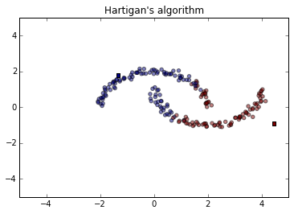

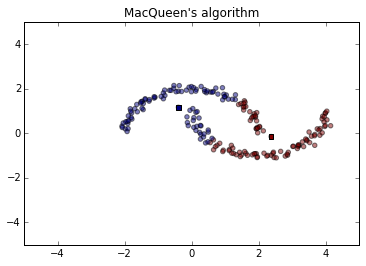

```python
demo_2_2(my_data)
```

## Apply Spectral Clustering on Data

### Play around the number of halfs

- See how the number of halfs changes

```
1 103
2 103
3 101
4 100
Got 4  with 100 each
5 100
Got 5  with 100 each
6 101
7 101
8 109
9 124
10 106
11 103
12 104
13 114
14 118
15 120
16 122
17 122
18 122
19 107
```

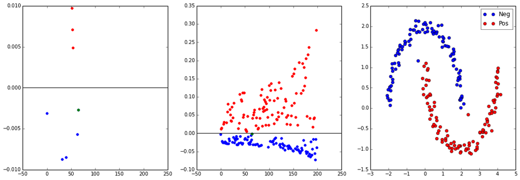

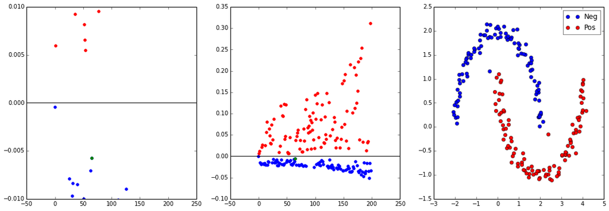

```python
demo_2_4(my_data)
```

## Exam the Laplacian Matrix

- S = exp(-beta* |x_i-x_j|^2) which is indepandent on the data order
- D = Sum(j to n)(Sij) if i=j which is depandent on the data order
- L = D - S

### Shuffle the data order to see the result

- we would have a differnet beta or even unable to get one sometime. Sometimes we got a lot
- But we see that the upper half gathered close to y=0 line, while the lower half spread around.

```
Got 3
Got 4
```

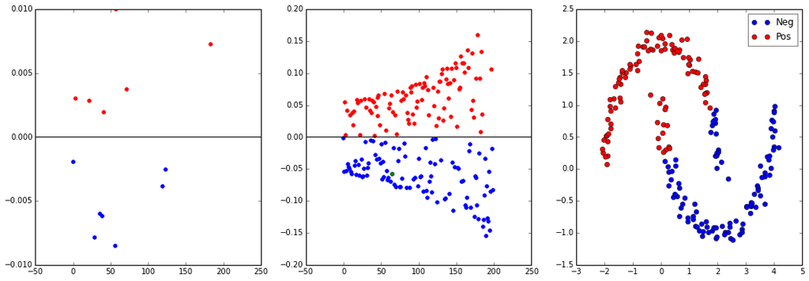

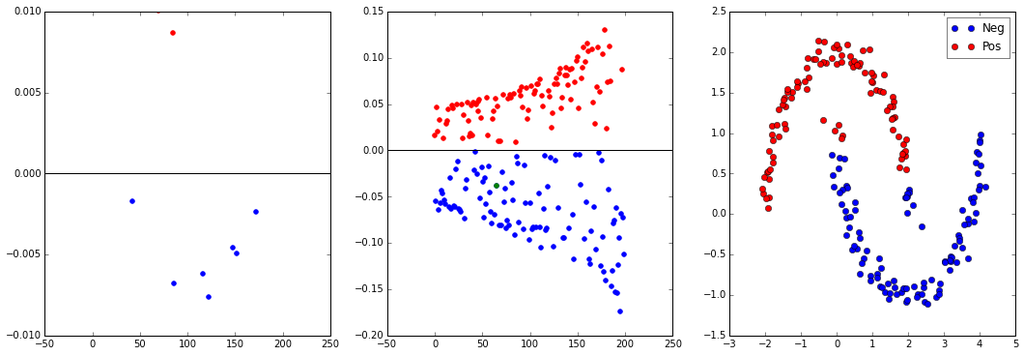

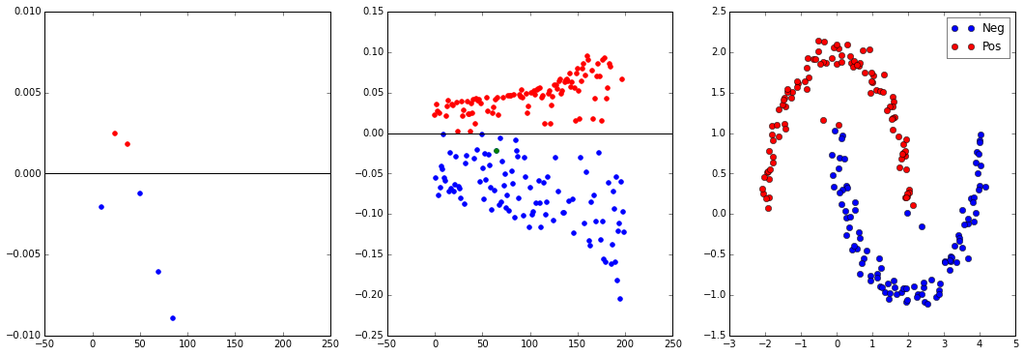

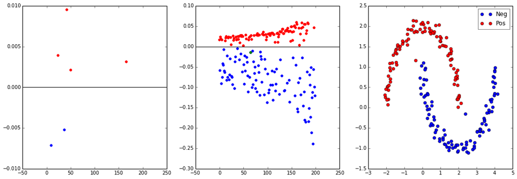

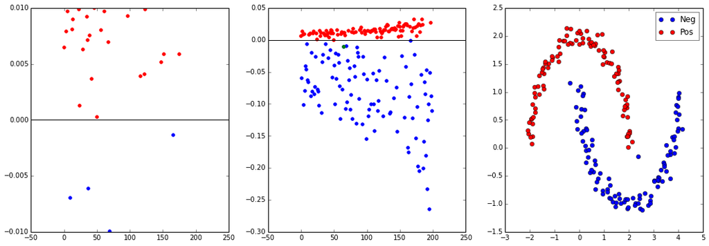

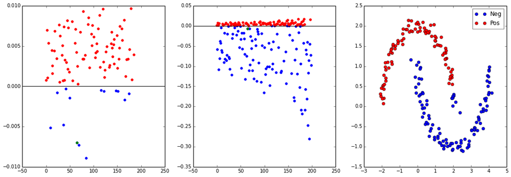

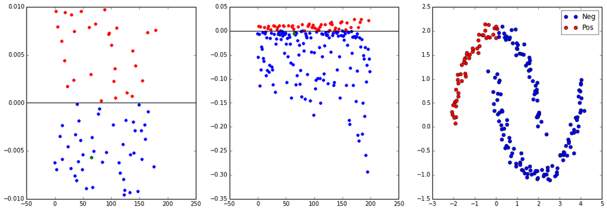

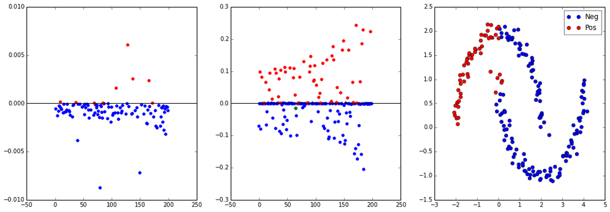

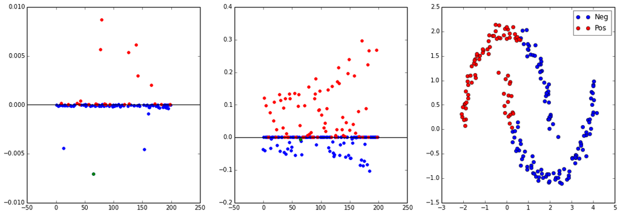

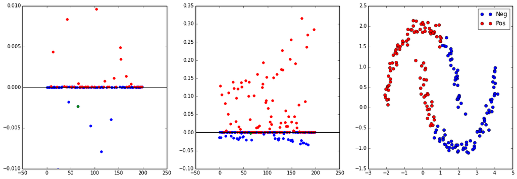

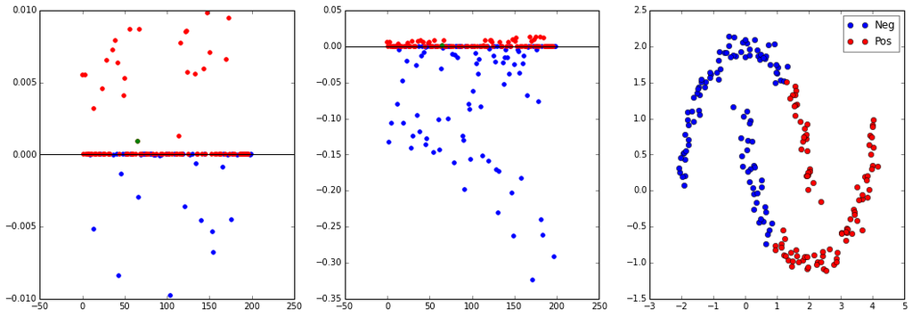

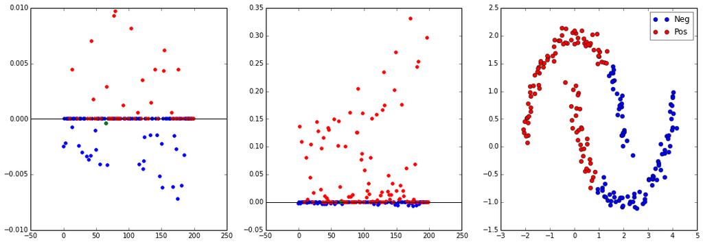

[7 more figures not shown]

```python
demo_2_5(my_data)
```